# Report 3

Advay Vyas

September 18, 2025

# Introduction

This week, I plan to use the methods I mentioned last week to estimate the WIS differences. I’ll process and prepare the data and then apply several models to try and see which work best.

# Data processing

I should have looked at this more but I really didn’t. It looks cool though! Off the top of my head, I see that pct_urban and pop_ratio seem to be the more correlated with other variables. Especially for diff_wis_h3, those are the first two that pop out from that row quite prominently (foreshadowing).

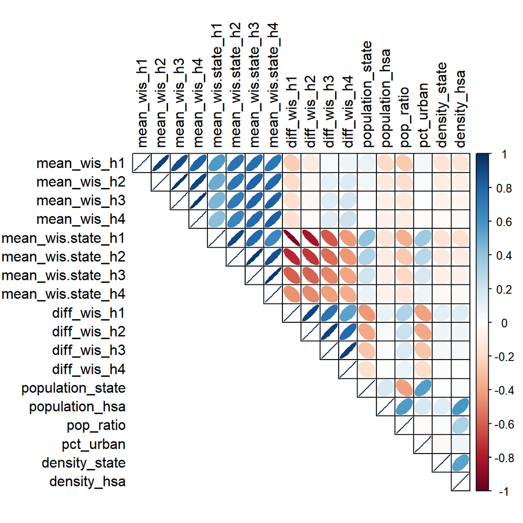

```r
df <- readr::read_csv("GBQR_diff_wis.csv", show_col_types = FALSE)

df_season <- df %>%
  filter(season == "2023/24")

cor_matrix = cor(df[, 4:ncol(df_season)])
# corrplot.mixed(cor_matrix, tl.col = "black", tl.pos = "lt", addgrid.col = TRUE, upper="color", lower="number", diag="l")
corrplot(cor_matrix, tl.col = "black", tl.pos = "lt", addgrid.col = TRUE, type = "upper", method = "ellipse", diag = TRUE)
```

# Support Vector Regression (SVR)

## Theoretical background

This model basically attempts to bring the benefits of support vector machines to regression. It fits a function within a margin of tolerance and can capture complex nonlinear relationships. It is also inherently regularized by its cost and penalty attributes.

## Implementation

```r
library(e1071)
```

### Feature Importance

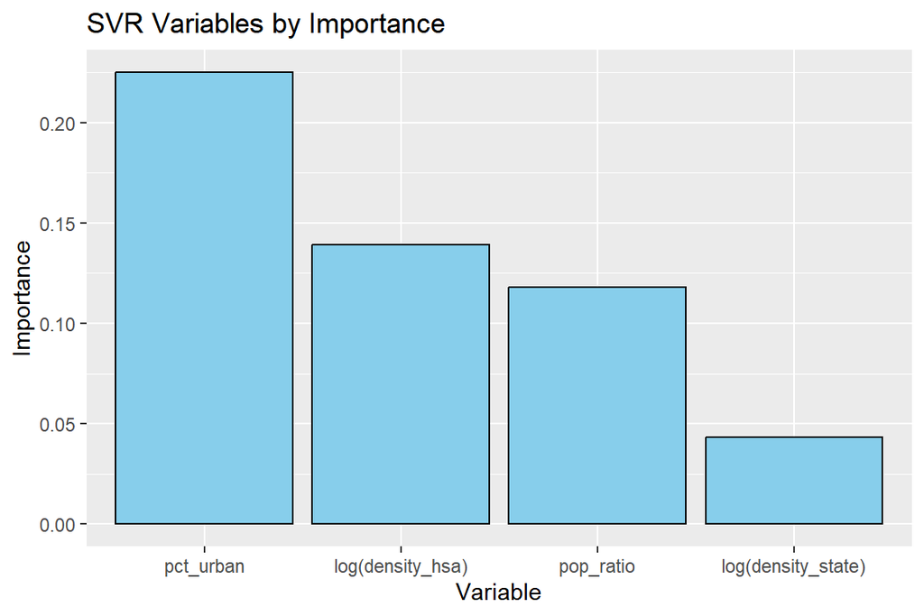

```r
svr_fit_linear = svm(diff_wis_h3 ~ pop_ratio + pct_urban +
                log(density_state) + log(density_hsa), data = df_season, type = "eps-regression", kernel = "linear")
svr_coefs = coef(svr_fit_linear)

svr_coefs_df = data.frame(
  variable = names(svr_coefs),
  coef     = as.numeric(svr_coefs)
)

svr_coefs_df = svr_coefs_df[2:5,]

svr_coefs_df$importance = abs(svr_coefs_df$coef)

# sort by importance descending
svr_coefs_df = svr_coefs_df[order(-svr_coefs_df$importance), ]

ggplot(svr_coefs_df) + geom_col(aes(x = reorder(variable, -importance), y = importance), fill='skyblue', col='black') + labs(x = "Variable", y = "Importance", title = "SVR Variables by Importance")
```

For SVR, it looks like pct_urban is the most important variable followed by the density of the hsa, then the pop ratio and the density of the state.

### Predictions

```r
B = 200
preds_boot = matrix(NA, nrow = nrow(df_season), ncol = B)
set.seed(1)

for (b in 1:B) {
  idx = sample(seq_len(nrow(df_season)), replace = TRUE)
  svr_b = svm(diff_wis_h3 ~ pop_ratio + pct_urban +
                log(density_state) + log(density_hsa),
              data = df_season[idx, ],
              type = "eps-regression", kernel = "radial",
              cost = 1, epsilon = 0.1)
  preds_boot[, b] = predict(svr_b, newdata = df_season)
}

ci_low  = apply(preds_boot, 1, quantile, probs = 0.025)
ci_high = apply(preds_boot, 1, quantile, probs = 0.975)
pred_median = apply(preds_boot, 1, median)

svr_predictions = data.frame(
  observed = df_season$diff_wis_h3,
  estimate = pred_median,
  ci_low = ci_low,
  ci_high = ci_high
)

coverage_95_svr = mean(
  svr_predictions$observed >= svr_predictions$ci_low &
  svr_predictions$observed <= svr_predictions$ci_high,
  na.rm = TRUE
)
```

This is a decent coverage level. While it is less than GAM, I think this approach has potential with some hyperparameter tuning and tweaks to how the model is applied. Right now, it is a very basic setup so it could improve. Still iffy on this one in the future.

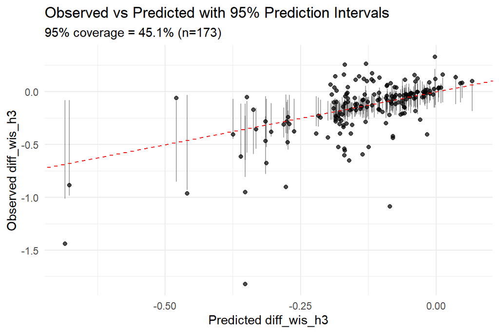

```r
ggplot(svr_predictions, aes(x = estimate, y = observed)) +
  geom_errorbar(aes(ymin = ci_low, ymax = ci_high), width = 0, alpha = 0.35) +
  geom_point(alpha = 0.7) +
  geom_abline(slope = 1, intercept = 0, linetype = "dashed", color = "red") +
  labs(x = "Predicted diff_wis_h3", y = "Observed diff_wis_h3",
       title = "Observed vs Predicted with 95% Prediction Intervals",
       subtitle = sprintf("95%% coverage = %.1f%% (n=%d)", 100*coverage_95_svr, nrow(svr_predictions))) +
  theme_minimal()
```

# Bayesian Additive Regression Trees (BART)

## Theoretical background

This model is able to use multiple trees to spread out complex predictors and effects. It also has in-built feature importance and natively returns confidence intervals, which is really useful.

## Implementation

```r
library(dbarts)
bart_fit <- bart(
  x.train = df_season[, c("pop_ratio","pct_urban",
                          "density_state","density_hsa")],
  y.train = df_season$diff_wis_h3,
  verbose = FALSE, keeptrees = TRUE
)
```

### Feature Importance

We use variable inclusion proportions as a way to check the importance of each variable. They all look pretty even for now.

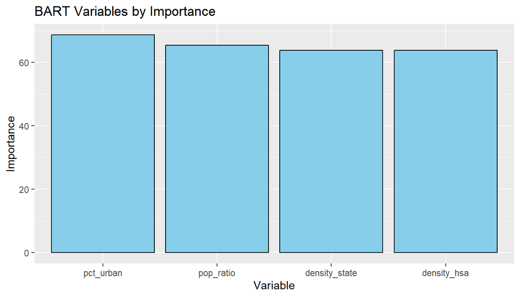

```r
bart_vi = as.data.frame(bart_fit$varcount) %>%
  summarise(across(everything(), ~ mean(.x, na.rm = TRUE))) %>%
  pivot_longer(cols = everything(),
               names_to = "variable",
               values_to = "avg")


ggplot(bart_vi) + geom_col(aes(x = reorder(variable, -avg), y = avg), fill='skyblue', col='black') + labs(x = "Variable", y = "Importance", title = "BART Variables by Importance")
```

Similar to SVR, pct_urban and the densities are important. However, what is interesting is that this method is the only method for which native feature importance is supported and they all seem equal. It also performs the best.

### Predictions

```r
pred = predict(bart_fit, newdata = df_season)
bart_predictions = as.data.frame(t(apply(pred, 2, quantile, probs = c(0.025, 0.975))))
colnames(bart_predictions) = c("ci_low", "ci_high")

bart_predictions$estimate = (bart_predictions$ci_low + bart_predictions$ci_high) / 2
bart_predictions$observed = df_season$diff_wis_h3

coverage_95_bart = mean(
  bart_predictions$observed >= bart_predictions$ci_low &
  bart_predictions$observed <= bart_predictions$ci_high,
  na.rm = TRUE
)
```

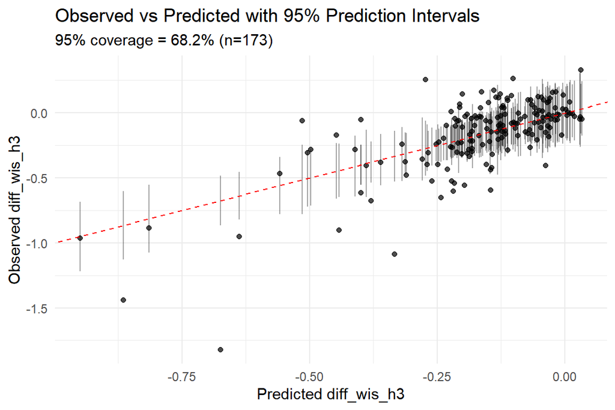

```r
ggplot(bart_predictions, aes(x = estimate, y = observed)) +
  geom_errorbar(aes(ymin = ci_low, ymax = ci_high), width = 0, alpha = 0.35) +
  geom_point(alpha = 0.7) +
  geom_abline(slope = 1, intercept = 0, linetype = "dashed", color = "red") +
  labs(x = "Predicted diff_wis_h3", y = "Observed diff_wis_h3",
       title = "Observed vs Predicted with 95% Prediction Intervals",
       subtitle = sprintf("95%% coverage = %.1f%% (n=%d)", 100*coverage_95_bart, nrow(bart_predictions))) +
  theme_minimal()
```

# LASSO

## Theoretical background

LASSO is basically linear regression that also penalizes large coefficients and performs automatic variable selection. More useful with many predictors or noisy/irrelvant predictors $\Rightarrow$ not really our case right now.

## Implementation

```r
library(glmnet)
# full predictor matrix and outcome
X_all = model.matrix(diff_wis_h3 ~ pop_ratio + pct_urban +
                       log(density_state) + log(density_hsa),
                     data = df_season)[, -1]
y_all = df_season$diff_wis_h3

# 80% training for bootstrapping
set.seed(123)
n = nrow(X_all)
train_idx = sample(seq_len(n), size = floor(0.8 * n))
X_train = X_all[train_idx, , drop = FALSE]
y_train = y_all[train_idx]

# predict for all 173 observations
X_test_full = X_all

# fit LASSO with CV to select lambda
cv_lasso = cv.glmnet(x = X_train, y = y_train, alpha = 1, nfolds = 10)
lasso_lambda = cv_lasso$lambda.min

# bootstrap
B = 200
preds_boot = matrix(NA, nrow = nrow(X_test_full), ncol = B)
set.seed(1)

for (b in 1:B) {
  idx = sample(seq_len(nrow(X_train)), replace = TRUE)
  fit_b = glmnet(x = X_train[idx, , drop = FALSE],
                 y = y_train[idx],
                 alpha = 1,
                 lambda = lasso_lambda)
  preds_boot[, b] = predict(fit_b, newx = X_test_full, s = lasso_lambda)[,1]
}

# 95% prediction intervals
ci_low  = apply(preds_boot, 1, quantile, probs = 0.025)
ci_high = apply(preds_boot, 1, quantile, probs = 0.975)

# median point estimate across bootstraps
pred_median = apply(preds_boot, 1, median)

# combine into a data frame
lasso_predictions = data.frame(
  observed = y_all,
  estimate = pred_median,
  ci_low = ci_low,
  ci_high = ci_high
)

coverage_95_lasso = mean(
  lasso_predictions$observed >= lasso_predictions$ci_low &
  lasso_predictions$observed <= lasso_predictions$ci_high,
  na.rm = TRUE
)
```

### Feature importance

Looks like it ignores two of the variables??? Interesting choice but okay. This must be the LASSO shrinking unimportant variables to 0. Interestingly enough, it also chose pct_urban as the most important followed up by a surprising pop_ratio.

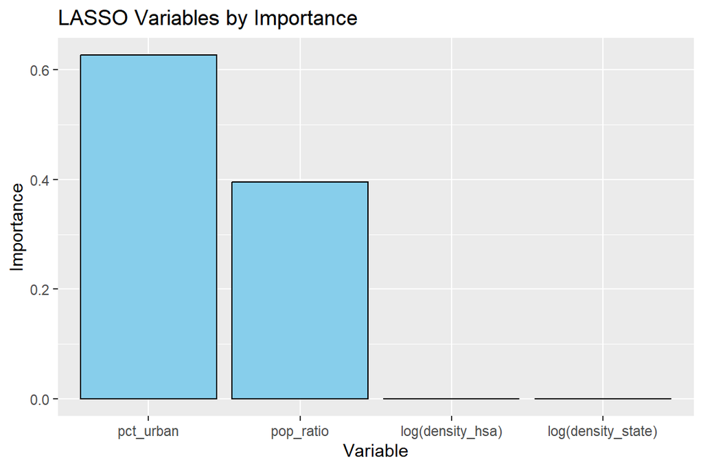

```r
lasso_coef = coef(cv_lasso, s = "lambda.min")  # already fitted with CV
lasso_coefs_df = data.frame(
  variable = rownames(lasso_coef)[-1],   # drop intercept
  coef     = as.numeric(lasso_coef[-1])
)

lasso_coefs_df$importance = abs(lasso_coefs_df$coef)

ggplot(lasso_coefs_df) + geom_col(aes(x = reorder(variable, -importance), y = importance), fill='skyblue', col='black') + labs(x = "Variable", y = "Importance", title = "LASSO Variables by Importance")
```

### Predictions

Yikes, all over the place fr. Not looking good for LASSO. I don’t like this at all.

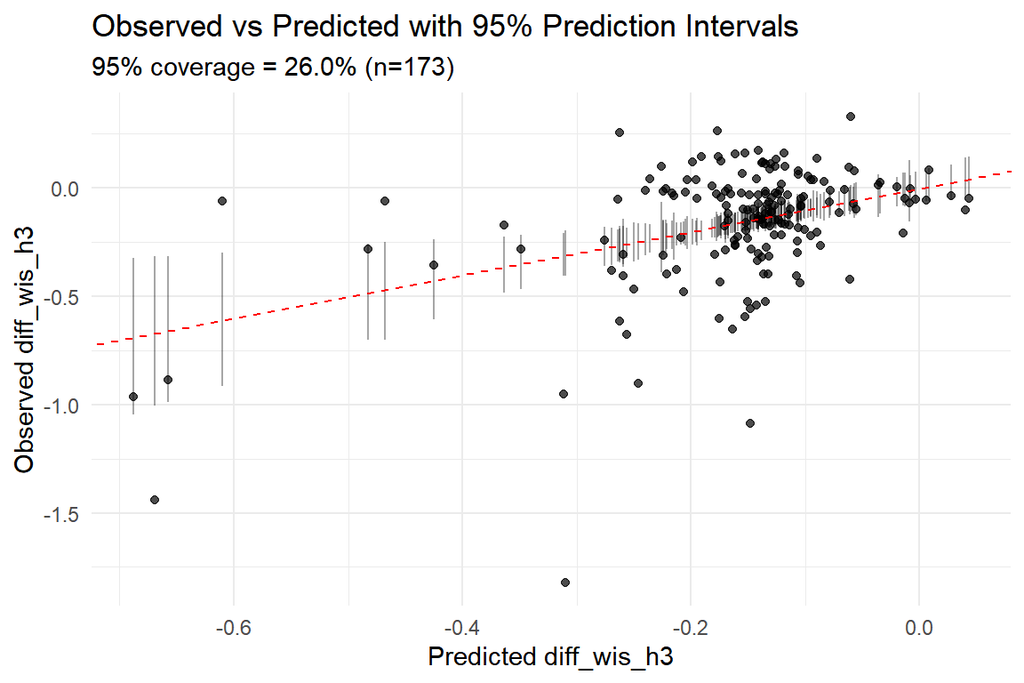

```r
ggplot(lasso_predictions, aes(x = estimate, y = observed)) +
  geom_errorbar(aes(ymin = ci_low, ymax = ci_high), width = 0, alpha = 0.35) +
  geom_point(alpha = 0.7) +
  geom_abline(slope = 1, intercept = 0, linetype = "dashed", color = "red") +
  labs(x = "Predicted diff_wis_h3", y = "Observed diff_wis_h3",
       title = "Observed vs Predicted with 95% Prediction Intervals",
       subtitle = sprintf("95%% coverage = %.1f%% (n=%d)", 100*coverage_95_lasso, nrow(bart_predictions))) +
  theme_minimal()
```

# Conclusion

I think BART and SVR look the most promising out of these three models, with BART for sure the best right now. I also need to look into bootstrapping the coefficients for feature importance on SVR and LASSO but I kind of ran out of time. I also want to look at elastic net and ridge instead of LASSO from glmnet and see how they differ or improve if at all. I also was unable to understand the US map code to project it onto a map, I want to make those next week or a bit later to see how that works with mine and easily compare. Lastly, I might look into using more variables to accurately predict how well the model will perform.